# Описание проекта: Телекоммуникации

"ТелеДом" ищет способы эффективного идентифицирования клиентов, которые могут потенциально разорвать договор. Чтобы предотвратить их уход, компания планирует предлагать индивидуальные промокоды и специальные условия.

**Цель проекта:**

Разработка предсказательной модели, способной с высокой точностью определять абонентов, склонных к отказу от услуг "ТелеДома". Модель должна анализировать персональные данные клиентов, информацию о подключенных услугах, тарифах и истории платежей.

**Задачи проекта:**

- Исследовать и подготовить предоставленные данные для анализа.
- Обучить различные модели машинного обучения для прогнозирования оттока.
- Оценить качество моделей, используя соответствующие метрики.
- Выбрать наиболее подходящую модель для внедрения на основе AUC-ROC и других релевантных метрик.
- Предоставить рекомендации "ТелеДому" по применению модели для уменьшения оттока клиентов.

**Ожидаемый результат:**

"ТелеДом" будет обладать надежным инструментом для прогнозирования риска оттока, что позволит оперативно реагировать и принимать меры по удержанию клиентов.

**Исходные данные для анализа:**

contract_new.csv — информация о договорах клиентов;

personal_new.csv — персональные данные клиентов;

internet_new.csv — информация об использовании интернет-услуг;

phone_new.csv — данные об использовании услуг телефонии.

# Импорт библиотек

```python
!pip install phik

!pip install -U scikit-learn

!pip install imbalanced-learn

!pip install shap
```

[output not shown]

```python
import pandas as pd
import os
import numpy as np
import seaborn as sns
import matplotlib.pyplot as plt
import phik

from phik import report
from phik.report import plot_correlation_matrix

from sklearn.preprocessing import OneHotEncoder, PowerTransformer, StandardScaler
from sklearn.compose import ColumnTransformer
from imblearn.pipeline import Pipeline as ImbPipeline
from sklearn.linear_model import LogisticRegression
from sklearn.model_selection import train_test_split, cross_val_score, GridSearchCV
from catboost import CatBoostClassifier
from sklearn.experimental import enable_halving_search_cv
from sklearn.metrics import make_scorer
from sklearn.feature_selection import VarianceThreshold
from sklearn.metrics import roc_auc_score, accuracy_score, confusion_matrix
from catboost import cv, Pool
from sklearn.model_selection import KFold, StratifiedKFold, cross_val_score
from imblearn.over_sampling import SMOTE
```

## Загрузка данных

```python
pth_contract = '/datasets/contract_new.csv'
pth_personal = '/datasets/personal_new.csv'
pth_internet = '/datasets/internet_new.csv'
pth_phone = '/datasets/phone_new.csv'

def load_data(path):
    if os.path.exists(path):
        return pd.read_csv(path)
    else:
        print(f'Файл не найден по пути: {path}')
        return None

contract_df = load_data(pth_contract)
personal_df = load_data(pth_personal)
internet_df = load_data(pth_internet)
phone_df = load_data(pth_phone)
```

```python
def analyze_df(df):
    print("Обзор DataFrame:")
    display(df.head())
    display(df.describe())
    print(df.info())
    print("\nКоличество пропущенных значений в каждом столбце:")
    print(df.isnull().sum())
    print("\nУникальные значения в каждом столбце:")
    for col in df.columns:
        print(f"{col}: {df[col].nunique()} уникальных значений")
```

## Исследовательский анализ и предобработка данных

```python
analyze_df(contract_df)
```

```
Обзор DataFrame:
```

|  | customerID | BeginDate | EndDate | Type | PaperlessBilling | PaymentMethod | MonthlyCharges | TotalCharges |
| --- | --- | --- | --- | --- | --- | --- | --- | --- |
| 0 | 7590-VHVEG | 2020-01-01 | No | Month-to-month | Yes | Electronic check | 29.85 | 31.04 |
| 1 | 5575-GNVDE | 2017-04-01 | No | One year | No | Mailed check | 56.95 | 2071.84 |
| 2 | 3668-QPYBK | 2019-10-01 | No | Month-to-month | Yes | Mailed check | 53.85 | 226.17 |
| 3 | 7795-CFOCW | 2016-05-01 | No | One year | No | Bank transfer (automatic) | 42.30 | 1960.6 |
| 4 | 9237-HQITU | 2019-09-01 | No | Month-to-month | Yes | Electronic check | 70.70 | 353.5 |

|  | MonthlyCharges |
| --- | --- |
| count | 7043.000000 |
| mean | 64.761692 |
| std | 30.090047 |
| min | 18.250000 |
| 25% | 35.500000 |
| 50% | 70.350000 |
| 75% | 89.850000 |
| max | 118.750000 |

```
<class 'pandas.core.frame.DataFrame'>
RangeIndex: 7043 entries, 0 to 7042
Data columns (total 8 columns):
 #   Column            Non-Null Count  Dtype
---  ------            --------------  -----
 0   customerID        7043 non-null   object
 1   BeginDate         7043 non-null   object
 2   EndDate           7043 non-null   object
 3   Type              7043 non-null   object
 4   PaperlessBilling  7043 non-null   object
 5   PaymentMethod     7043 non-null   object
 6   MonthlyCharges    7043 non-null   float64
 7   TotalCharges      7043 non-null   object
dtypes: float64(1), object(7)
memory usage: 440.3+ KB
None

Количество пропущенных значений в каждом столбце:
customerID          0
BeginDate           0
EndDate             0
Type                0
PaperlessBilling    0
PaymentMethod       0
MonthlyCharges      0
TotalCharges        0
dtype: int64

Уникальные значения в каждом столбце:
customerID: 7043 уникальных значений
BeginDate: 77 уникальных значений
EndDate: 67 уникальных значений
Type: 3 уникальных значений
PaperlessBilling: 2 уникальных значений
PaymentMethod: 4 уникальных значений
MonthlyCharges: 1585 уникальных значений
TotalCharges: 6658 уникальных значений
```

```python
analyze_df(personal_df)
```

```
Обзор DataFrame:
```

|  | customerID | gender | SeniorCitizen | Partner | Dependents |
| --- | --- | --- | --- | --- | --- |
| 0 | 7590-VHVEG | Female | 0 | Yes | No |
| 1 | 5575-GNVDE | Male | 0 | No | No |
| 2 | 3668-QPYBK | Male | 0 | No | No |
| 3 | 7795-CFOCW | Male | 0 | No | No |
| 4 | 9237-HQITU | Female | 0 | No | No |

|  | SeniorCitizen |
| --- | --- |
| count | 7043.000000 |
| mean | 0.162147 |
| std | 0.368612 |
| min | 0.000000 |
| 25% | 0.000000 |
| 50% | 0.000000 |
| 75% | 0.000000 |
| max | 1.000000 |

```
<class 'pandas.core.frame.DataFrame'>
RangeIndex: 7043 entries, 0 to 7042
Data columns (total 5 columns):
 #   Column         Non-Null Count  Dtype
---  ------         --------------  -----
 0   customerID     7043 non-null   object
 1   gender         7043 non-null   object
 2   SeniorCitizen  7043 non-null   int64
 3   Partner        7043 non-null   object
 4   Dependents     7043 non-null   object
dtypes: int64(1), object(4)
memory usage: 275.2+ KB
None

Количество пропущенных значений в каждом столбце:
customerID       0
gender           0
SeniorCitizen    0
Partner          0
Dependents       0
dtype: int64

Уникальные значения в каждом столбце:
customerID: 7043 уникальных значений
gender: 2 уникальных значений
SeniorCitizen: 2 уникальных значений
Partner: 2 уникальных значений
Dependents: 2 уникальных значений
```

```python
columns_to_analyze = ['BeginDate', 'EndDate', 'Type', 'PaymentMethod', 'MonthlyCharges', 'TotalCharges']

for col in columns_to_analyze:
    unique_values = contract_df[col].unique()
    n_unique_values = contract_df[col].nunique()
    print(f"Уникальные значения в столбце {col}:")
    print(unique_values)
    print(f"Количество уникальных значений: {n_unique_values}")
    print("\n")
```

```
Уникальные значения в столбце BeginDate:
['2020-01-01' '2017-04-01' '2019-10-01' '2016-05-01' '2019-09-01'
 '2019-03-01' '2018-04-01' '2019-04-01' '2017-07-01' '2014-12-01'
 '2019-01-01' '2018-10-01' '2015-04-01' '2015-09-01' '2018-01-01'
 '2014-05-01' '2015-10-01' '2014-03-01' '2018-05-01' '2019-11-01'
 '2019-02-01' '2016-01-01' '2017-08-01' '2015-12-01' '2014-02-01'
 '2018-06-01' '2019-12-01' '2017-11-01' '2019-06-01' '2016-04-01'
 '2017-02-01' '2018-12-01' '2014-04-01' '2018-09-01' '2014-11-01'
 '2016-07-01' '2015-02-01' '2018-07-01' '2014-08-01' '2016-03-01'
 '2018-08-01' '2014-10-01' '2015-06-01' '2016-08-01' '2019-05-01'
 '2017-03-01' '2016-02-01' '2017-09-01' '2014-09-01' '2017-12-01'
 '2016-12-01' '2017-06-01' '2015-05-01' '2016-10-01' '2016-09-01'
 '2019-08-01' '2019-07-01' '2017-05-01' '2017-10-01' '2014-07-01'
 '2018-03-01' '2015-01-01' '2018-11-01' '2015-03-01' '2018-02-01'
 '2016-06-01' '2015-08-01' '2015-11-01' '2014-06-01' '2017-01-01'
 '2015-07-01' '2020-02-01' '2016-11-01' '2013-11-01' '2014-01-01'
 '2013-10-01' '2013-12-01']
Количество уникальных значений: 77


Уникальные значения в столбце EndDate:
['No' '2017-05-01' '2016-03-01' '2018-09-01' '2018-11-01' '2018-12-01'
 '2019-08-01' '2018-07-01' '2017-09-01' '2015-09-01' '2016-07-01'
 '2016-06-01' '2018-03-01' '2019-02-01' '2018-06-01' '2019-06-01'
 '2020-01-01' '2019-11-01' '2016-09-01' '2015-06-01' '2016-12-01'
 '2019-05-01' '2019-04-01' '2017-06-01' '2017-08-01' '2018-04-01'
 '2018-08-01' '2018-02-01' '2019-07-01' '2015-12-01' '2014-06-01'
 '2018-10-01' '2019-01-01' '2017-07-01' '2017-12-01' '2018-05-01'
 '2015-11-01' '2019-10-01' '2019-03-01' '2016-02-01' '2016-10-01'
 '2018-01-01' '2017-11-01' '2015-10-01' '2019-12-01' '2015-07-01'
 '2017-04-01' '2015-02-01' '2017-03-01' '2016-05-01' '2016-11-01'
 '2015-08-01' '2019-09-01' '2017-10-01' '2017-02-01' '2016-08-01'
 '2016-04-01' '2015-05-01' '2014-09-01' '2014-10-01' '2017-01-01'
 '2015-03-01' '2015-01-01' '2016-01-01' '2015-04-01' '2014-12-01'
 '2014-11-01']
Количество уникальных значений: 67


Уникальные значения в столбце Type:
['Month-to-month' 'One year' 'Two year']
Количество уникальных значений: 3


Уникальные значения в столбце PaymentMethod:
['Electronic check' 'Mailed check' 'Bank transfer (automatic)'
 'Credit card (automatic)']
Количество уникальных значений: 4


Уникальные значения в столбце MonthlyCharges:
[29.85 56.95 53.85 ... 63.1  44.2  78.7 ]
Количество уникальных значений: 1585


Уникальные значения в столбце TotalCharges:
['31.04' '2071.84' '226.17' ... '325.6' '520.8' '7251.82']
Количество уникальных значений: 6658
```

```python
analyze_df(internet_df)
```

```
Обзор DataFrame:
```

|  | customerID | InternetService | OnlineSecurity | OnlineBackup | DeviceProtection | TechSupport | StreamingTV | StreamingMovies |
| --- | --- | --- | --- | --- | --- | --- | --- | --- |
| 0 | 7590-VHVEG | DSL | No | Yes | No | No | No | No |
| 1 | 5575-GNVDE | DSL | Yes | No | Yes | No | No | No |
| 2 | 3668-QPYBK | DSL | Yes | Yes | No | No | No | No |
| 3 | 7795-CFOCW | DSL | Yes | No | Yes | Yes | No | No |
| 4 | 9237-HQITU | Fiber optic | No | No | No | No | No | No |

|  | customerID | InternetService | OnlineSecurity | OnlineBackup | DeviceProtection | TechSupport | StreamingTV | StreamingMovies |
| --- | --- | --- | --- | --- | --- | --- | --- | --- |
| count | 5517 | 5517 | 5517 | 5517 | 5517 | 5517 | 5517 | 5517 |
| unique | 5517 | 2 | 2 | 2 | 2 | 2 | 2 | 2 |
| top | 0314-TKOSI | Fiber optic | No | No | No | No | No | No |
| freq | 1 | 3096 | 3498 | 3088 | 3095 | 3473 | 2810 | 2785 |

```
<class 'pandas.core.frame.DataFrame'>
RangeIndex: 5517 entries, 0 to 5516
Data columns (total 8 columns):
 #   Column            Non-Null Count  Dtype
---  ------            --------------  -----
 0   customerID        5517 non-null   object
 1   InternetService   5517 non-null   object
 2   OnlineSecurity    5517 non-null   object
 3   OnlineBackup      5517 non-null   object
 4   DeviceProtection  5517 non-null   object
 5   TechSupport       5517 non-null   object
 6   StreamingTV       5517 non-null   object
 7   StreamingMovies   5517 non-null   object
dtypes: object(8)
memory usage: 344.9+ KB
None

Количество пропущенных значений в каждом столбце:
customerID          0
InternetService     0
OnlineSecurity      0
OnlineBackup        0
DeviceProtection    0
TechSupport         0
StreamingTV         0
StreamingMovies     0
dtype: int64

Уникальные значения в каждом столбце:
customerID: 5517 уникальных значений
InternetService: 2 уникальных значений
OnlineSecurity: 2 уникальных значений
OnlineBackup: 2 уникальных значений
DeviceProtection: 2 уникальных значений
TechSupport: 2 уникальных значений
StreamingTV: 2 уникальных значений
StreamingMovies: 2 уникальных значений
```

```python
analyze_df(phone_df)
```

```
Обзор DataFrame:
```

|  | customerID | MultipleLines |
| --- | --- | --- |
| 0 | 5575-GNVDE | No |
| 1 | 3668-QPYBK | No |
| 2 | 9237-HQITU | No |
| 3 | 9305-CDSKC | Yes |
| 4 | 1452-KIOVK | Yes |

|  | customerID | MultipleLines |
| --- | --- | --- |
| count | 6361 | 6361 |
| unique | 6361 | 2 |
| top | 5574-NXZIU | No |
| freq | 1 | 3390 |

```
<class 'pandas.core.frame.DataFrame'>
RangeIndex: 6361 entries, 0 to 6360
Data columns (total 2 columns):
 #   Column         Non-Null Count  Dtype
---  ------         --------------  -----
 0   customerID     6361 non-null   object
 1   MultipleLines  6361 non-null   object
dtypes: object(2)
memory usage: 99.5+ KB
None

Количество пропущенных значений в каждом столбце:
customerID       0
MultipleLines    0
dtype: int64

Уникальные значения в каждом столбце:
customerID: 6361 уникальных значений
MultipleLines: 2 уникальных значений
```

**ПРЕДВАРИТЕЛЬНЫЙ ИСЛЕДОВАТЕЛЬСКИЙ АНАЛИЗ:**

Данные уже загружены, проведен первичный осмотр

- В каждом из датасетов customerID являются уникальными, что позволяет использовать их в качестве ключей для объединения данных.
- Пропущенные значения отсутствуют в исходных датасетах.
- В данных присутствует категориальные и числовые переменные, включая типы контрактов, способы оплаты, месячные платежи и общую сумму платежей.

```python
for df in [contract_df, personal_df, internet_df, phone_df]:
    if df['customerID'].nunique() != len(df):
        print("Обнаружены дубликаты customerID.")
    else:
        print("Все customerID уникальны.")
```

```
Все customerID уникальны.
Все customerID уникальны.
Все customerID уникальны.
Все customerID уникальны.
```

**Предобработка contract_df**

Создаем целевой бинарный признак. EndDate пока оставим для дальнейшей работы

```python
contract_df['active_contract'] = 1
contract_df.loc[contract_df['EndDate'] == 'No', 'active_contract'] = 0
contract_df[['EndDate', 'active_contract']].head()
```

|  | EndDate | active_contract |
| --- | --- | --- |
| 0 | No | 0 |
| 1 | No | 0 |
| 2 | No | 0 |
| 3 | No | 0 |
| 4 | No | 0 |

```python
contract_df['BeginDate'] = pd.to_datetime(
    contract_df['BeginDate'],
    format='%Y-%m-%d'
)

contract_df.loc[contract_df['EndDate'] == 'No', 'EndDate'] = '2020-02-01'
contract_df['EndDate'] = pd.to_datetime(
    contract_df['EndDate'],
    format='%Y-%m-%d'
)
```

```python
contract_df['duration_contract'] = (contract_df['EndDate'] - contract_df['BeginDate']).dt.components.days

contract_df = contract_df.drop(['BeginDate', 'EndDate'], axis=1)
```

```python
contract_df.loc[contract_df['TotalCharges'] == ' ', 'TotalCharges'] = 0
contract_df['TotalCharges'] = contract_df['TotalCharges'].astype('float64')

display(contract_df)
```

|  | customerID | Type | PaperlessBilling | PaymentMethod | MonthlyCharges | TotalCharges | active_contract | duration_contract |
| --- | --- | --- | --- | --- | --- | --- | --- | --- |
| 0 | 7590-VHVEG | Month-to-month | Yes | Electronic check | 29.85 | 31.04 | 0 | 31 |
| 1 | 5575-GNVDE | One year | No | Mailed check | 56.95 | 2071.84 | 0 | 1036 |
| 2 | 3668-QPYBK | Month-to-month | Yes | Mailed check | 53.85 | 226.17 | 0 | 123 |
| 3 | 7795-CFOCW | One year | No | Bank transfer (automatic) | 42.30 | 1960.60 | 0 | 1371 |
| 4 | 9237-HQITU | Month-to-month | Yes | Electronic check | 70.70 | 353.50 | 0 | 153 |
| ... | ... | ... | ... | ... | ... | ... | ... | ... |
| 7038 | 6840-RESVB | One year | Yes | Mailed check | 84.80 | 2035.20 | 0 | 730 |
| 7039 | 2234-XADUH | One year | Yes | Credit card (automatic) | 103.20 | 7430.40 | 0 | 2191 |
| 7040 | 4801-JZAZL | Month-to-month | Yes | Electronic check | 29.60 | 325.60 | 0 | 337 |
| 7041 | 8361-LTMKD | Month-to-month | Yes | Mailed check | 74.40 | 520.80 | 0 | 215 |
| 7042 | 3186-AJIEK | Two year | Yes | Bank transfer (automatic) | 105.65 | 7251.82 | 0 | 2010 |

7043 rows × 8 columns

**ПРОМЕЖУТОЧНЫЕ ВЫВОДЫ ПО ПРЕДОБРАБОТКЕ**

Пробелы в столбце TotalCharges связаны с клиентами, которые еще не совершили платежи или подписались на услуги недавно, то замена пробелов нулями может отражать отсутствие платежей или начальное состояние баланса.

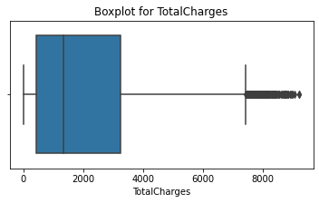

```
Корреляционная матрица числовых признаков после обработки:
                MonthlyCharges  TotalCharges
MonthlyCharges         1.00000       0.63044
TotalCharges           0.63044       1.00000
```

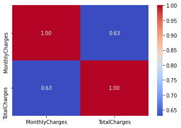

```python
plt.figure(figsize=(6, 3))
sns.boxplot(data=contract_df, x='TotalCharges')
plt.title('Boxplot for TotalCharges')
plt.show()


numerical_cols = ['MonthlyCharges', 'TotalCharges']

correlation_matrix = contract_df[numerical_cols].corr()
print("\nКорреляционная матрица числовых признаков после обработки:")
print(correlation_matrix)

sns.heatmap(correlation_matrix, annot=True, fmt='.2f', cmap='coolwarm')
plt.show()
```

```
Корреляция между TotalCharges и active_contract: 0.05217479162845562
```

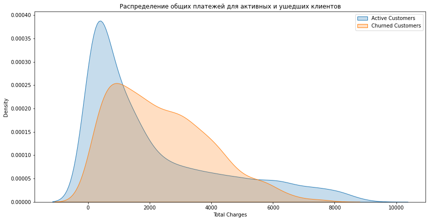

```python
correlation = contract_df['TotalCharges'].corr(contract_df['active_contract'])
print(f"Корреляция между TotalCharges и active_contract: {correlation}")

plt.figure(figsize=(14, 7))
sns.kdeplot(contract_df[contract_df['active_contract'] == 0]['TotalCharges'], label='Active Customers', shade=True)
sns.kdeplot(contract_df[contract_df['active_contract'] == 1]['TotalCharges'], label='Churned Customers', shade=True)
plt.title('Распределение общих платежей для активных и ушедших клиентов')
plt.xlabel('Total Charges')
plt.ylabel('Density')
plt.legend()
plt.show()
```

**Предобработка personal_df**

```python
print(personal_df.isnull().sum())
```

```
customerID       0
gender           0
SeniorCitizen    0
Partner          0
Dependents       0
dtype: int64
```

```python
print('Размерность датафрейма "contract_df":', contract_df.shape)
print('Размерность датафрейма "personal_df":', personal_df.shape)
print('Размерность датафрейма "internet_df":', internet_df.shape)
print('Размерность датафрейма "phone_df":', phone_df.shape)
```

```
Размерность датафрейма "contract_df": (7043, 8)
Размерность датафрейма "personal_df": (7043, 5)
Размерность датафрейма "internet_df": (5517, 8)
Размерность датафрейма "phone_df": (6361, 2)
```

## Объединение данных

```python
full_df = contract_df.merge(personal_df, on='customerID', how='left') \
                     .merge(internet_df, on='customerID', how='left') \
                     .merge(phone_df, on='customerID', how='left')

print("Объединённый датафрейм:")
analyze_df(full_df)
```

```
Объединённый датафрейм:
Обзор DataFrame:
```

|  | customerID | Type | PaperlessBilling | PaymentMethod | MonthlyCharges | TotalCharges | active_contract | duration_contract | gender | SeniorCitizen | Partner | Dependents | InternetService | OnlineSecurity | OnlineBackup | DeviceProtection | TechSupport | StreamingTV | StreamingMovies | MultipleLines |
| --- | --- | --- | --- | --- | --- | --- | --- | --- | --- | --- | --- | --- | --- | --- | --- | --- | --- | --- | --- | --- |
| 0 | 7590-VHVEG | Month-to-month | Yes | Electronic check | 29.85 | 31.04 | 0 | 31 | Female | 0 | Yes | No | DSL | No | Yes | No | No | No | No | NaN |
| 1 | 5575-GNVDE | One year | No | Mailed check | 56.95 | 2071.84 | 0 | 1036 | Male | 0 | No | No | DSL | Yes | No | Yes | No | No | No | No |
| 2 | 3668-QPYBK | Month-to-month | Yes | Mailed check | 53.85 | 226.17 | 0 | 123 | Male | 0 | No | No | DSL | Yes | Yes | No | No | No | No | No |
| 3 | 7795-CFOCW | One year | No | Bank transfer (automatic) | 42.30 | 1960.60 | 0 | 1371 | Male | 0 | No | No | DSL | Yes | No | Yes | Yes | No | No | NaN |
| 4 | 9237-HQITU | Month-to-month | Yes | Electronic check | 70.70 | 353.50 | 0 | 153 | Female | 0 | No | No | Fiber optic | No | No | No | No | No | No | No |

|  | MonthlyCharges | TotalCharges | active_contract | duration_contract | SeniorCitizen |
| --- | --- | --- | --- | --- | --- |
| count | 7043.000000 | 7043.000000 | 7043.000000 | 7043.000000 | 7043.000000 |
| mean | 64.761692 | 2115.312885 | 0.156325 | 898.555729 | 0.162147 |
| std | 30.090047 | 2112.742814 | 0.363189 | 683.130510 | 0.368612 |
| min | 18.250000 | 0.000000 | 0.000000 | 0.000000 | 0.000000 |
| 25% | 35.500000 | 436.750000 | 0.000000 | 276.000000 | 0.000000 |
| 50% | 70.350000 | 1343.350000 | 0.000000 | 761.000000 | 0.000000 |
| 75% | 89.850000 | 3236.690000 | 0.000000 | 1461.000000 | 0.000000 |
| max | 118.750000 | 9221.380000 | 1.000000 | 2314.000000 | 1.000000 |

```
<class 'pandas.core.frame.DataFrame'>
Int64Index: 7043 entries, 0 to 7042
Data columns (total 20 columns):
 #   Column             Non-Null Count  Dtype
---  ------             --------------  -----
 0   customerID         7043 non-null   object
 1   Type               7043 non-null   object
 2   PaperlessBilling   7043 non-null   object
 3   PaymentMethod      7043 non-null   object
 4   MonthlyCharges     7043 non-null   float64
 5   TotalCharges       7043 non-null   float64
 6   active_contract    7043 non-null   int64
 7   duration_contract  7043 non-null   int64
 8   gender             7043 non-null   object
 9   SeniorCitizen      7043 non-null   int64
 10  Partner            7043 non-null   object
 11  Dependents         7043 non-null   object
 12  InternetService    5517 non-null   object
 13  OnlineSecurity     5517 non-null   object
 14  OnlineBackup       5517 non-null   object
 15  DeviceProtection   5517 non-null   object
 16  TechSupport        5517 non-null   object
 17  StreamingTV        5517 non-null   object
 18  StreamingMovies    5517 non-null   object
 19  MultipleLines      6361 non-null   object
dtypes: float64(2), int64(3), object(15)
memory usage: 1.1+ MB
None

Количество пропущенных значений в каждом столбце:
customerID              0
Type                    0
PaperlessBilling        0
PaymentMethod           0
MonthlyCharges          0
TotalCharges            0
active_contract         0
duration_contract       0
gender                  0
SeniorCitizen           0
```

[output cut: 18 more lines]

```
TotalCharges: 6658 уникальных значений
active_contract: 2 уникальных значений
duration_contract: 251 уникальных значений
gender: 2 уникальных значений
SeniorCitizen: 2 уникальных значений
Partner: 2 уникальных значений
Dependents: 2 уникальных значений
InternetService: 2 уникальных значений
OnlineSecurity: 2 уникальных значений
OnlineBackup: 2 уникальных значений
DeviceProtection: 2 уникальных значений
TechSupport: 2 уникальных значений
StreamingTV: 2 уникальных значений
StreamingMovies: 2 уникальных значений
MultipleLines: 2 уникальных значений
```

```
Уникальных customerID: 7043 из 7043 строк
Количество дубликатов строк: 0

Пропущенные значения в каждом столбце:
InternetService     1526
OnlineSecurity      1526
OnlineBackup        1526
DeviceProtection    1526
TechSupport         1526
StreamingTV         1526
StreamingMovies     1526
MultipleLines        682
dtype: int64
```

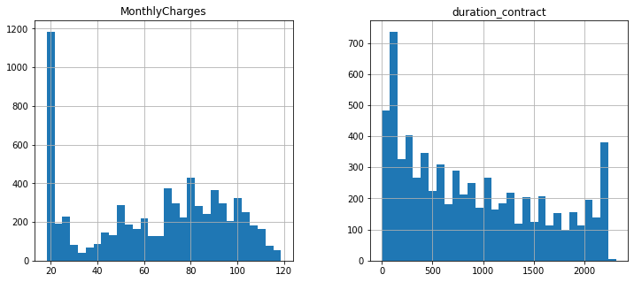

```python
unique_customer_ids = full_df['customerID'].nunique()
print(f"Уникальных customerID: {unique_customer_ids} из {len(full_df)} строк")
duplicate_rows = full_df.duplicated().sum()
print(f"Количество дубликатов строк: {duplicate_rows}")

missing_values = full_df.isnull().sum()
print("\nПропущенные значения в каждом столбце:")
print(missing_values[missing_values > 0])

numeric_features = ['MonthlyCharges','duration_contract']
full_df[numeric_features].hist(bins=30, figsize=(12, 5))
plt.show()
```

## Исследовательский анализ и предобработка данных объединённого датафрейма

**Анализ распределения и дисбаланса классов**

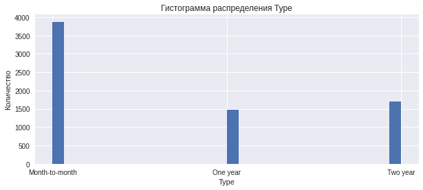

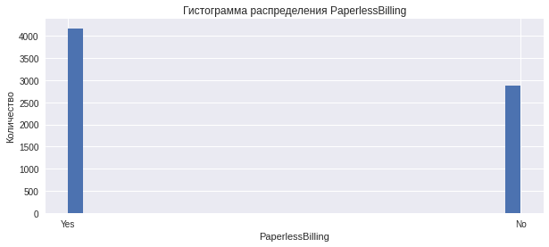

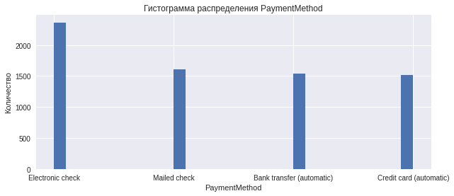

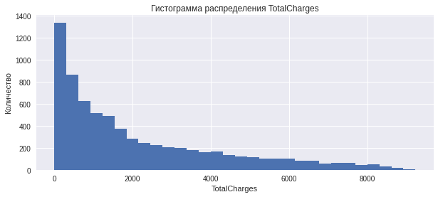

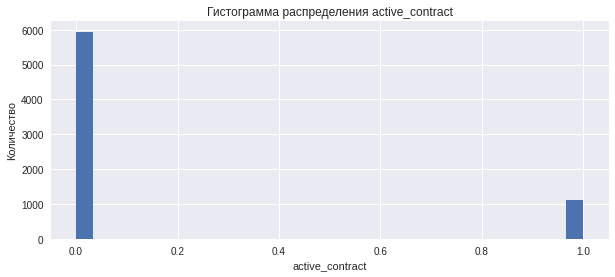

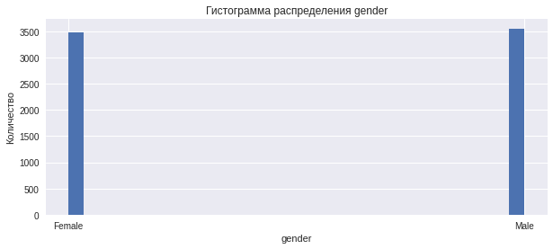

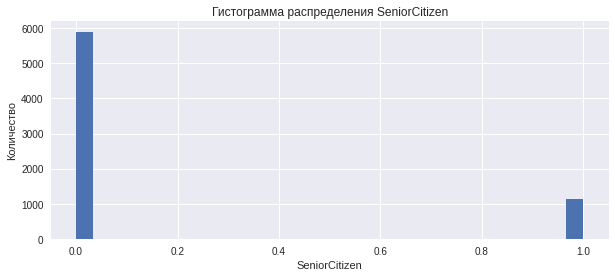

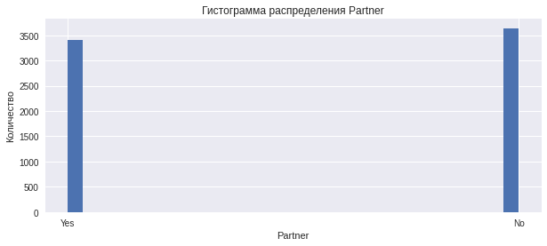

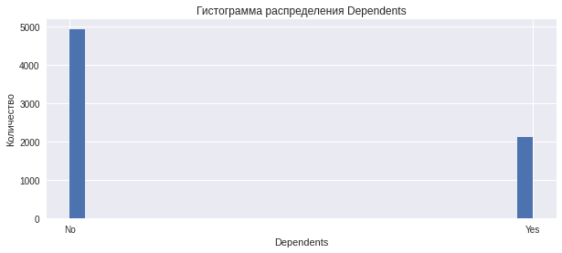

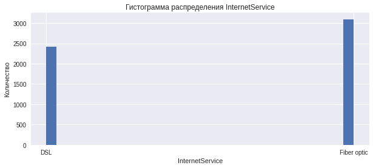

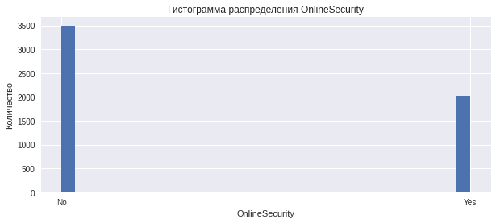

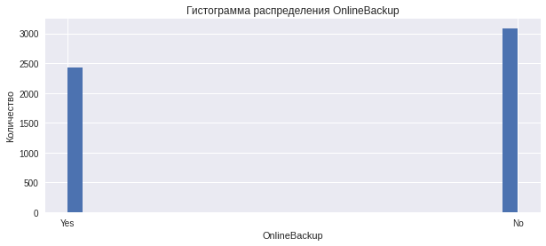

[5 more figures not shown]

```python
plt.style.use('seaborn')

def plot_histograms(df, features):
    for feature in features:
        plt.figure(figsize=(10, 4))
        df[feature].hist(bins=30)
        plt.title(f'Гистограмма распределения {feature}')
        plt.xlabel(feature)
        plt.ylabel('Количество')
        plt.show()

plot_histograms(full_df, ['Type','PaperlessBilling', 'PaymentMethod', 'TotalCharges', 'active_contract',
    'gender', 'SeniorCitizen', 'Partner', 'Dependents', 'InternetService',
    'OnlineSecurity', 'OnlineBackup', 'DeviceProtection', 'TechSupport',
    'StreamingTV', 'StreamingMovies', 'MultipleLines'])
```

```
Класс 0: 5942
Класс 1: 1101
```

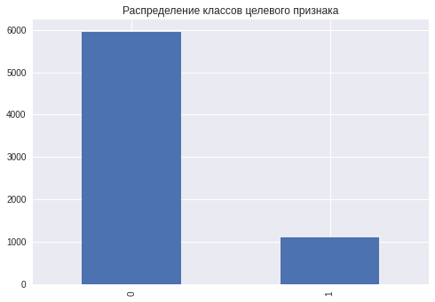

```python
class_counts = full_df['active_contract'].value_counts()
print("Класс 0:", class_counts[0])
print("Класс 1:", class_counts[1])
class_counts.plot(kind='bar')
plt.title('Распределение классов целевого признака')
plt.show()
```

```python
print(f"Общее количество клиентов: {full_df.shape[0]}")
print(f"Количество активных контрактов (Класс 0): {class_counts[0]}")
print(f"Количество расторгнутых контрактов (Класс 1): {class_counts[1]}")
print(f"Процент активных контрактов: {class_counts[0] / full_df.shape[0] * 100:.2f}%")
print(f"Процент расторгнутых контрактов: {class_counts[1] / full_df.shape[0] * 100:.2f}%")
```

```
Общее количество клиентов: 7043
Количество активных контрактов (Класс 0): 5942
Количество расторгнутых контрактов (Класс 1): 1101
Процент активных контрактов: 84.37%
Процент расторгнутых контрактов: 15.63%
```

```python
categorical_features = []
for i in full_df.columns:
    if (i not in numeric_features) & (i not in ['customerID', 'active_contract', 'TotalCharges']):
        categorical_features.append(i)

display('Количество категориальных признаков:', len(categorical_features))
full_df[categorical_features].head()
```

```
'Количество категориальных признаков:'
```

```
15
```

|  | Type | PaperlessBilling | PaymentMethod | gender | SeniorCitizen | Partner | Dependents | InternetService | OnlineSecurity | OnlineBackup | DeviceProtection | TechSupport | StreamingTV | StreamingMovies | MultipleLines |
| --- | --- | --- | --- | --- | --- | --- | --- | --- | --- | --- | --- | --- | --- | --- | --- |
| 0 | Month-to-month | Yes | Electronic check | Female | 0 | Yes | No | DSL | No | Yes | No | No | No | No | NaN |
| 1 | One year | No | Mailed check | Male | 0 | No | No | DSL | Yes | No | Yes | No | No | No | No |
| 2 | Month-to-month | Yes | Mailed check | Male | 0 | No | No | DSL | Yes | Yes | No | No | No | No | No |
| 3 | One year | No | Bank transfer (automatic) | Male | 0 | No | No | DSL | Yes | No | Yes | Yes | No | No | NaN |
| 4 | Month-to-month | Yes | Electronic check | Female | 0 | No | No | Fiber optic | No | No | No | No | No | No | No |

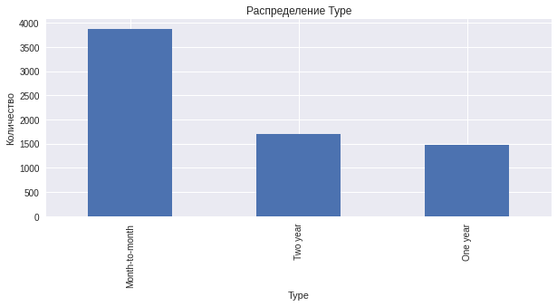

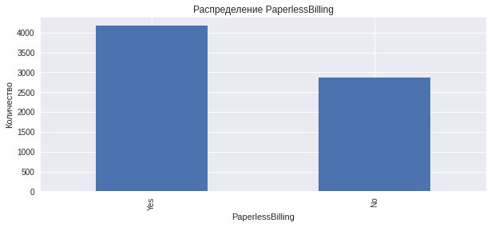

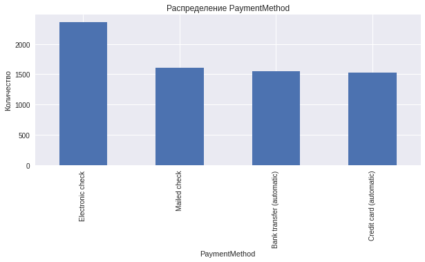

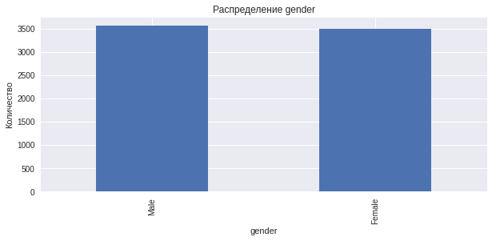

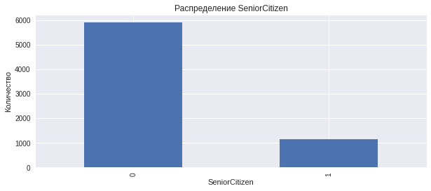

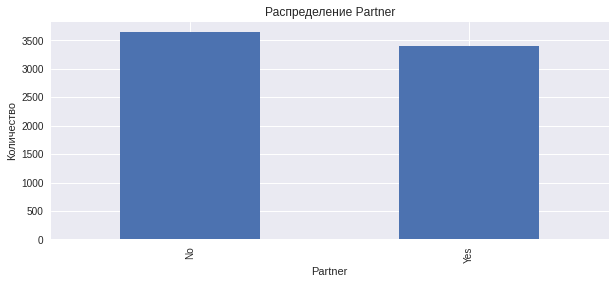

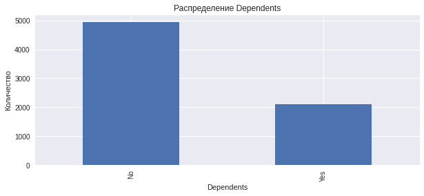

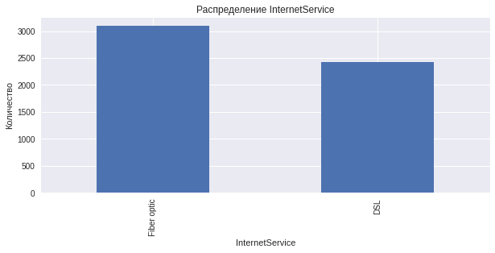

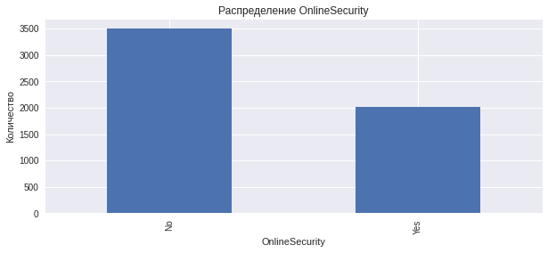

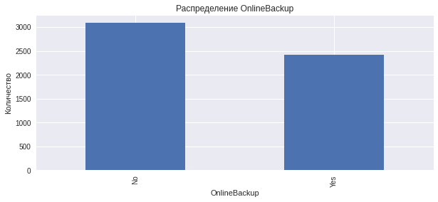

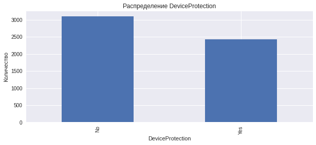

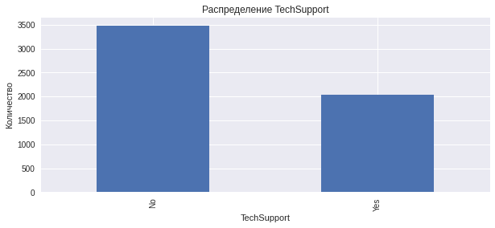

[3 more figures not shown]

```python
def plot_bar_charts(df, categorical_features):
    for feature in categorical_features:
        plt.figure(figsize=(10, 4))
        df[feature].value_counts().plot(kind='bar')
        plt.title(f'Распределение {feature}')
        plt.xlabel(feature)
        plt.ylabel('Количество')
        plt.show()

plot_bar_charts(full_df, categorical_features)
```

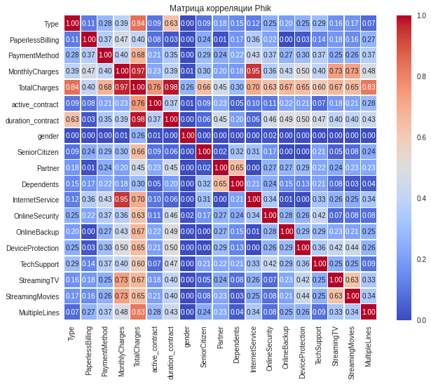

```
Отобранные признаки: ['PaymentMethod', 'MonthlyCharges', 'Partner', 'OnlineBackup', 'DeviceProtection', 'StreamingMovies']
Категориальные признаки: ['PaymentMethod', 'Partner', 'OnlineBackup', 'DeviceProtection', 'StreamingMovies']
Числовые признаки: ['MonthlyCharges']
```

```python
def select_features(correlation_mat, target, min_threshold =0.2, max_threshold =0.8):
    weak_correlated_features = set(correlation_mat.columns[(correlation_mat[target].abs() < min_threshold)])
    strongly_correlated_features = set()
    for i in range(len(correlation_mat.columns)):
        for j in range(i):
            if abs(correlation_mat.iloc[i, j]) > max_threshold and correlation_mat.columns[j] != target:
                colname = correlation_mat.columns[i]
                strongly_correlated_features.add(colname)

    selected_columns = [column for column in correlation_mat.columns if column not in weak_correlated_features
                        and column not in strongly_correlated_features and column != target]
    return selected_columns

correlation_matrix = full_df.drop(columns=['customerID']).phik_matrix(interval_cols=numeric_features)

plt.figure(figsize=(10, 8))
sns.heatmap(correlation_matrix, annot=True, fmt=".2f", cmap='coolwarm', linewidths=.5)
plt.title('Матрица корреляции Phik')
plt.show()

selected_features = select_features(correlation_matrix, target='active_contract', min_threshold=0.2, max_threshold=0.8)

print('Отобранные признаки:', selected_features)

features_categories = [feature for feature in selected_features if feature in categorical_features]
features_numeric = [feature for feature in selected_features if feature in numeric_features]

print('Категориальные признаки:', features_categories)
print('Числовые признаки:', features_numeric)
```

```python
categorical_features = ['Type','SeniorCitizen','Dependents', 'MultipleLines','InternetService']

numeric_features = ['MonthlyCharges', 'duration_contract']

target_variable = ['active_contract']
```

**Важная заметка**

Основываясь на исследовательском анализе, были выявлены признаки, которые потенциально могут влиять на отток клиентов. По этой причине в категориальные признаки были вручную добавлены важные характеристики.

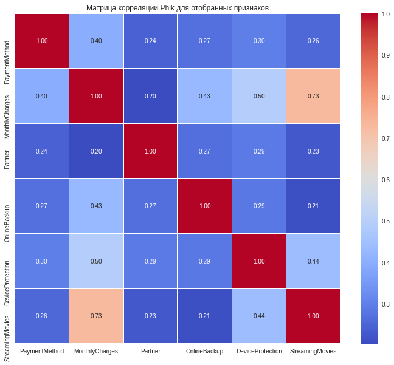

```python
selected_features_correlation_matrix = full_df[selected_features].phik_matrix(interval_cols=features_numeric)

plt.figure(figsize=(12, 10))
sns.heatmap(selected_features_correlation_matrix, annot=True, fmt=".2f", cmap='coolwarm', linewidths=.5)
plt.title('Матрица корреляции Phik для отобранных признаков')
plt.show()
```

**Анализ** TechSupport: Большинство клиентов не пользуются выделенной линией технической поддержки, что может свидетельствовать о недостаточной информированности о данной услуге или об отсутствии необходимости в ней у клиентов.

DeviceProtection: Количество клиентов, использующих антивирусную защиту устройства, меньше по сравнению с теми, кто не использует данную услугу, что может указывать на доверие к встроенным средствам защиты или на дополнительную стоимость услуги.

OnlineSecurity: Клиентов, не использующих блокировку небезопасных сайтов, больше, чем тех, кто пользуется данной услугой, что может быть связано с дополнительными расходами или недостаточной осведомленностью о преимуществах сервиса.

SeniorCitizen: Пенсионеров среди клиентов заметно меньше, что может коррелировать с меньшей заинтересованностью в технологиях или сложностями использования услуг.

Type: Наиболее популярным типом контракта является ежемесячная оплата, что подчеркивает предпочтение клиентов к гибкости и возможности не вкладываться в длительные обязательства. Годовые и двухгодичные контракты менее популярны, что может свидетельствовать о желании клиентов избегать долгосрочных финансовых обязательств.

OnlineSecurity: Больше клиентов отказывается от услуги блокировки опасных сайтов, что может указывать на недооценку рисков онлайн-безопасности или на высокую стоимость услуги.

Dependents: Большинство клиентов не имеют иждивенцев. Это может влиять на выбор тарифов и услуг, так как клиенты без иждивенцев, возможно, менее заинтересованы в семейных планах или услугах.

SeniorCitizen: Пенсионеров среди клиентов заметно меньше, что может быть связано с меньшим интересом к технологическим продуктам или предпочтением более традиционных способов общения и получения информации.

PaperlessBilling: Электронный способ выставления счетов, вероятно, более популярен среди клиентов, что отражает тренд на цифровизацию и удобство управления счетами онлайн.

PaymentMethod: Методы оплаты, вероятно, также смещены в сторону электронных форм, что отражает удобство и возможно более быстрое проведение платежей через интернет.

**Важные моменты:**

Были исключены характеристики с низкой и высокой корреляцией с целевой переменной.

Числовые признаки: 'MonthlyCharges', 'duration_contract'

## Подготовка данных

```python
STATE = 111223
```

```python
duplicates = full_df.duplicated(subset=categorical_features + numeric_features + ['active_contract']).sum()
print(f"Количество дубликатов: {duplicates}")

if duplicates > 0:
    full_df = full_df.drop_duplicates(subset=categorical_features + numeric_features + ['active_contract'])
    full_df = full_df.reset_index(drop=True)
```

```
Количество дубликатов: 185
```

```python
for col in numeric_features:
    null_count = full_df[col].isnull().sum()
    if null_count > 0:
        print(f"Колонка {col} имеет {null_count} пропущенных значений.")


for col in categorical_features:
    print(f"--- {col} ---")
    print(f"Уникальные значения:\n{full_df[col].unique()}")
    print(f"Количество пропущенных значений: {full_df[col]}")

full_df['MultipleLines'] = full_df['MultipleLines'].fillna('No service')
full_df['InternetService'] = full_df['InternetService'].fillna('No service')

print(f"Количество пропущенных значений в 'MultipleLines': {full_df['MultipleLines'].isnull().sum()}")
print(f"Количество пропущенных значений в 'InternetService': {full_df['InternetService'].isnull().sum()}")
```

[output not shown]

[output cut: 22 more lines]

```
['DSL' 'Fiber optic' nan]
Количество пропущенных значений: 0               DSL
1               DSL
2               DSL
3               DSL
4       Fiber optic
           ...
6853            DSL
6854    Fiber optic
6855            DSL
6856    Fiber optic
6857    Fiber optic
Name: InternetService, Length: 6858, dtype: object
Количество пропущенных значений в 'MultipleLines': 0
Количество пропущенных значений в 'InternetService': 0
```

```python
preprocessor_cb = ColumnTransformer(
    transformers=[
        ('num', StandardScaler(), numeric_features),
        ('cat', OneHotEncoder(drop='first', handle_unknown='ignore'), categorical_features)
    ]
)

preprocessor_lr = ColumnTransformer(
    transformers=[
        ('num', StandardScaler(), features_numeric),
        ('cat', OneHotEncoder(drop='first', handle_unknown='ignore'), features_categories)
    ]
)
```

```python
# CatBoost
X_cb = full_df.drop(['active_contract', 'customerID'], axis=1)
y_cb = full_df['active_contract']

X_train_cb, X_test_cb, y_train_cb, y_test_cb = train_test_split(
    X_cb, y_cb, test_size=0.25, random_state=STATE, stratify=y_cb
)

#Logistic Regression
X_lr = full_df[selected_features]
y_lr = full_df['active_contract']

X_train_lr, X_test_lr, y_train_lr, y_test_lr = train_test_split(
    X_lr, y_lr, test_size=0.25, random_state=STATE, stratify=y_lr
)
```

## Обучение моделей машинного обучения

**Модель CatBoost**

```python
cv = StratifiedKFold(n_splits=5, shuffle=True, random_state=STATE)

cb_pipeline = ImbPipeline(steps=[
    ('preprocessor', preprocessor_cb),
    ('smote', SMOTE(random_state=STATE)),
    ('classifier', CatBoostClassifier(random_state=STATE, verbose=100))
])
params_cb = {
    'classifier__iterations': [100, 500],
    'classifier__learning_rate': [0.01, 0.1],
    'classifier__depth': [4, 6],
    'classifier__eval_metric': ['AUC'],
    'classifier__auto_class_weights': ['Balanced']
}

grid_cb = GridSearchCV(cb_pipeline, params_cb, cv=cv, scoring='roc_auc')
grid_cb.fit(X_train_cb, y_train_cb)

print("Лучшие параметры для CatBoost:", grid_cb.best_params_)
print("Лучший ROC AUC на кросс-валидации:", grid_cb.best_score_)
```

[output not shown]

[output cut: 113 more lines]

[output not shown]

**LogisticRegression**

```python
lr_pipeline = ImbPipeline([
    ('preprocessor', preprocessor_lr),
    ('smote', SMOTE(random_state=STATE)),
    ('classifier', LogisticRegression(random_state=STATE))
])

params_lr = {
    'classifier__solver': ['liblinear', 'lbfgs', 'newton-cg'],
    'classifier__C': [0.1, 1, 10, 100]
}

grid_lr = GridSearchCV(lr_pipeline, params_lr, cv=4, scoring='roc_auc')
grid_lr.fit(X_train_lr, y_train_lr)

print("Лучшие параметры для Logistic Regression:", grid_lr.best_params_)
print("Лучший ROC AUC на кросс-валидации:", grid_lr.best_score_)
```

```
Лучшие параметры для Logistic Regression: {'classifier__C': 0.1, 'classifier__solver': 'newton-cg'}
Лучший ROC AUC на кросс-валидации: 0.7009125659047529
```

```python
print("Лучший ROC AUC для CatBoost:", grid_cb.best_score_)
print("Лучший ROC AUC для Logistic Regression:", grid_lr.best_score_)
```

```
Лучший ROC AUC для CatBoost: 0.9257506420471809
Лучший ROC AUC для Logistic Regression: 0.7009125659047529
```

**Результаты обучения** Средний ROC AUC для CatBoost: 0.92

Исходя из этих результатов, модель CatBoost показывает лучшую производительность по метрике ROC AUC.

## Выбор лучшей модели

```python
best_model_cb = grid_cb.best_estimator_
y_pred_probs_cb = best_model_cb.predict_proba(X_test_cb)[:, 1]

roc_auc_cb = roc_auc_score(y_test_cb, y_pred_probs_cb)
accuracy_cb = accuracy_score(y_test_cb, best_model_cb.predict(X_test_cb))

print(f'CatBoost - ROC AUC на тесте: {roc_auc_cb}')
print(f'CatBoost - Accuracy на тесте: {accuracy_cb}')
```

```
CatBoost - ROC AUC на тесте: 0.9122070707070706
CatBoost - Accuracy на тесте: 0.9306122448979591
```

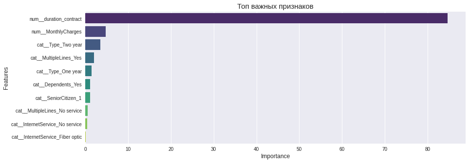

```python
best_pipeline = grid_cb.best_estimator_
feature_names = best_pipeline.named_steps['preprocessor'].get_feature_names_out()
feature_importances = best_pipeline.named_steps['classifier'].get_feature_importance()

importance_df = pd.DataFrame({
    'Feature': feature_names,
    'Importance': feature_importances
}).sort_values(by='Importance', ascending=False)

plt.figure(figsize=(14, 5))
sns.barplot(x='Importance', y='Feature', data=importance_df.head(10), palette='viridis')
plt.title('Топ важных признаков', fontsize=15)
plt.xlabel('Importance', fontsize=12)
plt.ylabel('Features', fontsize=12)
plt.show()
```

Продолжительность контракта: Время, в течение которого клиент остается с компанией, является наиболее значимым фактором для предсказания оттока клиентов. Длинные контракты могут свидетельствовать о высокой лояльности клиента, в то время как короткие контракты могут указывать на повышенный риск ухода.

Ежемесячные платежи: Вероятно, чем выше ежемесячные платежи, тем больше вероятность, что клиенты будут искать более выгодные предложения и, соответственно, уйдут к конкурентам.

Тип контракта:Это показывает, что длительность контрактов также играет значительную роль в оттоке клиентов, причем более длительные контракты, вероятно, связаны с более низким оттоком.

Зависимые: Наличие иждивенцев также может играть роль в решении остаться с текущим провайдером услуг, так как это может указывать на семейный план.

Пожилые граждане: Наличие пожилых граждан в данных может влиять на решения по оттоку, возможно, из-за различных потребностей или предпочтений в планах обслуживания.

Интернет-услуги: Пользователи с Fiber optic подключением к интернету могут иметь большие ожидания относительно качества и скорости услуг, что может влиять на их решение остаться или уйти

```
Sensitivity (True Positive Rate): 0.6981818181818182
Specificity (True Negative Rate): 0.975
Precision: 0.8421052631578947
F1 Score: 0.7634194831013916
```

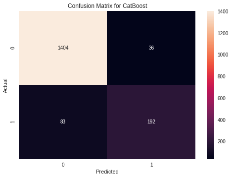

```python
conf_matrix = confusion_matrix(y_test_cb, (y_pred_probs_cb >= 0.5).astype(int))
tn, fp, fn, tp = conf_matrix.ravel()


sensitivity = tp / (tp + fn)
specificity = tn / (tn + fp)
precision = tp / (tp + fp)
f1_score = 2 * (precision * sensitivity) / (precision + sensitivity)

print(f'Sensitivity (True Positive Rate): {sensitivity}')
print(f'Specificity (True Negative Rate): {specificity}')
print(f'Precision: {precision}')
print(f'F1 Score: {f1_score}')


sns.heatmap(conf_matrix, annot=True, fmt="d")
plt.title('Confusion Matrix for CatBoost')
plt.xlabel('Predicted')
plt.ylabel('Actual')
plt.show()
```

Матрица ошибок демонстрирует эффективность модели CatBoost в прогнозировании удержания клиентов:

**Дополнительные метрики:**

Таким образом, модель CatBoost показала себя надёжной в определении ушедших клиентов с высокими значениями точности .

## Общий вывод и рекомендации заказчику

В рамках проекта был выполнен комплексный анализ данных клиентов телекоммуникационной компании с целью построения модели, предсказывающей отток клиентов. Этапы работы включали загрузку данных, исследовательский анализ, предобработку данных, обучение моделей машинного обучения и оценку их качества.

**Основные этапы работы:** Загрузка и первичный осмотр данных: Данные были успешно загружены из четырёх различных файлов и проверены на наличие пропусков и уникальности customerID.

**Предобработка данных:**

Созданы новые признаки: active_contract и duration_contract.

EndDate преобразован из "No" в дату для расчёта продолжительности контрактов.

Пропуски в TotalCharges обработаны, поля приведены к числовому формату.

**Объединение данных:** Различные датасеты были объединены в один общий датафрейм для удобства дальнейшего анализа и моделирования.

Исследовательский анализ и предобработка объединённого датафрейма:

Использована корреляционная матрица для анализа мультиколлинеарности и отбора признаков. Проведён отбор признаков, обладающих статистически значимой парной корреляцией с целевым признаком, и исключены мультиколлинеарные признаки.

**Обучение моделей:**

Были обучены две модели: CatBoost и логистическая регрессия.

Для CatBoost была достигнута метрика ROC AUC 0.92, что указывает на высокую предсказательную способность модели.

**Оценка качества моделей:**

**Результаты:** Лучшие параметры для CatBoost: {'classifier**auto_class_weights': 'Balanced', 'classifier**depth': 4, 'classifier**eval_metric': 'AUC', 'classifier**iterations': 500, 'classifier__learning_rate': 0.1}

**Выводы и рекомендации:**

- Фокус на удержание: Учитывая важность продолжительности договора, компании следует сфокусироваться на разработке стратегий для удержания клиентов, особенно в начале их жизненного цикла.
- Персонализированные предложения: Разработать персонализированные маркетинговые акции и предложения, основываясь на понимании важности ежемесячных платежей и партнерских отношений.
- Улучшение качества обслуживания: Поскольку некоторые услуги оказались важными для предсказания оттока, компании следует улучшить качество и доступность этих услуг для клиентов.
- Дальнейший анализ: Проводить регулярный мониторинг и анализ данных о клиентах для своевременного выявления изменений в поведении клиентов и адаптации стратегий удержания.